# K-近邻算法

## K-近邻算法(KNN，K-nearest neighbors)

K-近邻算法是通过测量与特征值之间的距离来进行**分类**

**K-近邻算法原理**：

有一个训练样本集，每条数据都有标签。输入没有标签的新数据后，将新数据与样本集中的数据对应特征进行距离计算，提取出最近的K条最近的数据，这样我们就得到了K个标签，其中出现次数最多的标签作为我们对于新数据的分类。

**优点：**对异常值不敏感，对少量数据有效，无需训练模型

**缺点：**计算复杂度高

### 补充知识

> 距离的定义： $设特征空间\chi是n维实数向量空间R^n,x_i,x_j\in\chi,x_i=(x_i^{(1)},x_i^{(2)},...,x_i^{(n)}),x_j=(x_i^{(1)},x_i^{(2)},...,x_i^{(n)}),x_i,x_j的L_p的距离定义为$ $$L_p(x_i,x_j)=\left(\sum_{l=i}^n |x_i^{(l)}-x_j^{(l)}|^p\right)^{\frac1p} ,这里p\ge1$$

> $当p＝2时，称为欧式距离，即L_p(x_i,x_j)=\left(\sum_{l=i}^n |x_i^{(l)}-x_j^{(l)}|^2\right)^{\frac12}$

> $当p＝1时，称为曼哈顿距离，即L_p(x_i,x_j)=\sum_{l=i}^n |x_i^{(l)}-x_j^{(l)}|$

> $当p＝\infty，他是各个坐标距离的最大值，即L_p(x_i,x_j)＝\max_l|x_i^{(l)}-x_j^{(l)}|$

### 伪代码

```
1. 计算待分类的点与已知类别数据集中的点的距离
2. 按照距离排序
3. 选取最近的K个点
4. 统计K个点中类别出现的频率
5. 出现最多的类别最为当前的预测分类
```

### 准备数据

```python
%pylab inline
import operator
```

```python
def createDataSet():
    group = array([[1.0,1.1],[1.0,1.0],[0,0],[0,0.1]])
    labels = ['A','A','B','B']
    return group, labels
```

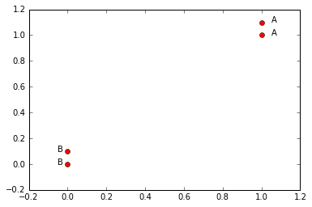

```python
group,labels=createDataSet()
plt.plot(group.T[0],group.T[1],'ro')
plt.axis([-0.2, 1.2, -0.2, 1.2])
plt.text(1.05,1, 'A')
plt.text(1.05,1.1, 'A')
plt.text(-0.05,0, 'B')
plt.text(-0.05,0.1, 'B')
```

```python
group
```

```
array([[ 1. ,  1.1],
       [ 1. ,  1. ],
       [ 0. ,  0. ],
       [ 0. ,  0.1]])
```

```python
labels
```

```
['A', 'A', 'B', 'B']
```

```python
'''
Input:      inX: vector to compare to existing dataset (1xN)
            dataSet: size m data set of known vectors (NxM)
            labels: data set labels (1xM vector)
            k: number of neighbors to use for comparison (should be an odd number)

Output:     the most popular class label

code copy from Harrington P. Machine learning in action[M]. Manning, 2012.
'''

def KNN_classify(inX, dataSet, labels, k):
    dataSetSize = dataSet.shape[0]  #计算数据集大小

    #计算距离
    diffMat = tile(inX, (dataSetSize,1)) - dataSet
    sqDiffMat = diffMat**2
    sqDistances = sqDiffMat.sum(axis=1)
    distances = sqDistances**0.5

    #排序并取前N个 标签
    sortedDistIndicies = distances.argsort()
    classCount={}
    for i in range(k):
        voteIlabel = labels[sortedDistIndicies[i]]
        classCount[voteIlabel] = classCount.get(voteIlabel,0) + 1
    sortedClassCount = sorted(iter(classCount.items()), key=operator.itemgetter(1), reverse=True)
    return sortedClassCount[0][0]

print("[0.1,0.2] -> ",KNN_classify([0.1,0.2],group,labels,3))
print("[1.1,0.9] -> ",KNN_classify([1.1,0.9],group,labels,3))
```

```
[0.1,0.2] ->  B
[1.1,0.9] ->  A
```

### KNN在sklearn库中的用法

```python
from sklearn.neighbors import KNeighborsClassifier
neigh = KNeighborsClassifier(n_neighbors=3)
neigh.fit(group, labels)
print("[0.1,0.2] -> ",neigh.predict([[0.1,0.2]]))
print("[1.1,0.9] -> ",neigh.predict([[1.1,0.9]]))
```

```
[0.1,0.2] ->  ['B']
[1.1,0.9] ->  ['A']
```

### 应用场景

- 推荐系统
  - 基于人的商品推荐，计算人之间的距离，推荐与你距离最近的人喜欢的新商品
  - 基于商品的推荐，计算你喜欢的商品与其它商品之间的距离，推荐距离近的新商品

> 江万 jiangwaniot@live.com 欢迎交流